# Text Classification - eRum2018

Lots of data are textual. We want to get closer to people thoughts.

Ananlysis framework + LIME

# Text mining

## Packages

```r
library(readr)
library(dplyr)
library(stringr)
library(lubridate)
library(ggplot2)
library(quanteda)
library(lime)
```

```
Error in library(lime) : there is no package called ‘lime’
```

Several packages do the text mining operations.

quanteda is easier for data exploration and data visualization, and contains some modelling inside.

## Data

```r
tweet_csv <- read_csv("tweets.csv")
str(tweet_csv, give.attr = FALSE)
```

```
Classes ‘tbl_df’, ‘tbl’ and 'data.frame':   6444 obs. of  28 variables:
 $ id                     : num  7.81e+17 7.81e+17 7.81e+17 7.81e+17 7.81e+17 ...
 $ handle                 : chr  "HillaryClinton" "HillaryClinton" "HillaryClinton" "HillaryClinton" ...
 $ text                   : chr  "The question in this election: Who can put the plans into action that will make your life better? https://t.co/XreEY9OicG" "Last night, Donald Trump said not paying taxes was \"smart.\" You know what I call it? Unpatriotic. https://t.co/t0xmBfj7zF" "Couldn't be more…
 $ is_retweet             : chr  "False" "True" "True" "False" ...
 $ original_author        : chr  NA "timkaine" "POTUS" NA ...
 $ time                   : POSIXct, format: "2016-09-28 00:22:34" "2016-09-27 23:45:00" ...
 $ in_reply_to_screen_name: chr  NA NA NA NA ...
 $ in_reply_to_status_id  : num  NA NA NA NA NA NA NA NA NA NA ...
 $ in_reply_to_user_id    : num  NA NA NA NA NA NA NA NA NA NA ...
 $ is_quote_status        : chr  "False" "False" "False" "False" ...
 $ lang                   : chr  "en" "en" "en" "en" ...
 $ retweet_count          : int  218 2445 7834 916 859 2181 1303 1833 4132 1087 ...
 $ favorite_count         : int  651 5308 27234 2542 2882 6172 2849 4954 11239 2824 ...
 $ longitude              : num  NA NA NA NA NA NA NA NA NA NA ...
 $ latitude               : num  NA NA NA NA NA NA NA NA NA NA ...
 $ place_id               : chr  NA NA NA NA ...
 $ place_full_name        : chr  NA NA NA NA ...
 $ place_name             : chr  NA NA NA NA ...
 $ place_type             : chr  NA NA NA NA ...
 $ place_country_code     : chr  NA NA NA NA ...
 $ place_country          : chr  NA NA NA NA ...
 $ place_contained_within : chr  NA NA NA NA ...
 $ place_attributes       : chr  NA NA NA NA ...
 $ place_bounding_box     : chr  NA NA NA NA ...
 $ source_url             : chr  "https://studio.twitter.com" "http://twitter.com" "https://about.twitter.com/products/tweetdeck" "https://studio.twitter.com" ...
 $ truncated              : chr  "False" "False" "False" "False" ...
 $ entities               : chr  "{'media': [{'display_url': 'pic.twitter.com/XreEY9OicG', 'expanded_url': 'https://twitter.com/HillaryClinton/st"| __truncated__ "{'media': [{'display_url': 'pic.twitter.com/t0xmBfj7zF', 'sizes': {'medium': {'h': 512, 'resize': 'fit', 'w': 1"| __truncated__ "{'user_m…
 $ extended_entities      : chr  "{'media': [{'display_url': 'pic.twitter.com/XreEY9OicG', 'sizes': {'medium': {'h': 675, 'resize': 'fit', 'w': 1"| __truncated__ "{'media': [{'display_url': 'pic.twitter.com/t0xmBfj7zF', 'sizes': {'medium': {'h': 512, 'resize': 'fit', 'w': 1"| __truncated__ NA "{'med…
```

## Little data explaration

```r
table(tweet_csv$handle, tweet_csv$is_retweet)
```

```
                  False True
  HillaryClinton   2629  597
  realDonaldTrump  3093  125
```

```r
table(tweet_csv$lang)
```

```
  da   en   es   et   fi   fr   tl  und
   3 6248  105    1    1    2    2   82
```

```r
table(tweet_csv$handle, tweet_csv$lang)
```

```
                    da   en   es   et   fi   fr   tl  und
  HillaryClinton     0 3117  102    0    0    1    0    6
  realDonaldTrump    3 3131    3    1    1    1    2   76
```

Clinton is retwitting more

## Data formatting

```r
tweet_data <- tweet_csv %>%
  #  filter(is_retweet == "False") %>%
  select(author = handle,
         text,
         retweet_count,
         favorite_count,
         source_url,
         timestamp = time) %>%
  mutate(date = as_date(str_sub(timestamp, 1, 10)),
         hour = hour(hms(str_sub(timestamp, 12, 19))),
         tweet_num = row_number()) %>%
  select(-timestamp)
```

## Bag of words

Order and punctuation doesn’t matter, just the frequency of words matters.

We will use just words and frequencies to predict the right class.

## Tokens

Strings or character strings are tockens. Tokensing means split into words and punctuation. You can also split into sentences, and personalize tokensing.

### Tokenizing single word

```r
example_text <- tweet_data$text[1]
quanteda::tokens(example_text, "word")
```

```
tokens from 1 document.
text1 :
 [1] "The"        "question"   "in"         "this"       "election"
 [6] ":"          "Who"        "can"        "put"        "the"
[11] "plans"      "into"       "action"     "that"       "will"
[16] "make"       "your"       "life"       "better"     "?"
[21] "https"      ":"          "/"          "/"          "t.co"
[26] "/"          "XreEY9OicG"
```

### Tokenizing 2 words (ngrams)

It’s possible to tokenize into n-grams (bigrams, trigrams etc)

```r
quanteda::tokens(example_text, "word", ngrams = 2)
```

```
tokens from 1 document.
text1 :
 [1] "The_question"  "question_in"   "in_this"       "this_election"
 [5] "election_:"    ":_Who"         "Who_can"       "can_put"
 [9] "put_the"       "the_plans"     "plans_into"    "into_action"
[13] "action_that"   "that_will"     "will_make"     "make_your"
[17] "your_life"     "life_better"   "better_?"      "?_https"
[21] "https_:"       ":_/"           "/_/"           "/_t.co"
[25] "t.co_/"        "/_XreEY9OicG"
```

### Tokenizing sentences

```r
quanteda::tokens(example_text, "sentence")
```

## Corpus

Collection of the document: corpus. It contains data and metadata.

```r
tweet_corpus <- quanteda::corpus(tweet_data)
```

We get documents plus metadata.

### Subset corpus data

```r
summary(quanteda::corpus_subset(tweet_corpus, date > as_date('2016-07-01')),
        n =nrow(tweet_data))
```

### Querying corpus data

```r
quanteda::kwic(tweet_corpus, "terror")
```

```
 [text1557, 17]            have to stand up against | terror |
  [text1639, 9]       to answer question about Iran | terror |
 [text1764, 19]       this is about RADICAL ISLAMIC | TERROR |
 [text2327, 22]      with the Afghan people against | terror |
 [text2904, 15]       breaks for families struck by | terror |
 [text3501, 23]        from nations tied to Islamic | terror |
 [text3513, 15]           who love freedom and hate | terror |
 [text3523, 19]         primary victory, to discuss | terror |
 [text3524, 17]      using the term Radical Islamic | Terror |
  [text3532, 7]                  This was an act of | terror |
 [text4053, 24]               be on the lookout for | terror |
 [text5163, 10]             best by far in fighting | terror |
  [text5164, 9]     deliver a prepackaged speech on | terror |
 [text5164, 16]       She's been in office fighting | terror |
 [text5175, 18]        so politically correct, that | terror |
  [text6283, 9] than anticipated in radical Islamic | terror |
 [text6413, 11]        station. Just announced that | terror |

 and come together to prevent
 funding. I won't dodge
 and the weakness of our
 .- H
 in Turkey, Iraq,
 .
 . It's wrong, and
 and the horrible events of
 . Hillary just broke-said she
 .... This
 and terrorists!
 . I'm the only one
 . She's been in office
 for 20 years- and
 groups are forming and getting
 attack yesterday. Get tough
 threat is at highest level
```

We get the side by side text of each tweet, around the given word.

If we want to check who is the author of something, we can run something like:

```r
corpus_subset(tweet_corpus, author == "realDonaldTrump")["text340"]
```

```
                                                                                                                                           text340
"Once again someone we were told is ok turns out to be a terrorist who wants to destroy our country &amp; its people- how did he get thru system?"
```

If we check using the Hillary Clinton name, we get an NA

```r
corpus_subset(tweet_corpus, author == "HillaryClinton")["text340"]
```

```
<NA>
  NA
```

Other checks:

```r
kwic(tweet_corpus, "immigrant*")
kwic(tweet_corpus, "famil*")
kwic(tweet_corpus, "thank")
```

## Explorative data viz

|  | Text | Types | Tokens | Sentences | author | retweet_count | favorite_count | source_url | date | hour | tweet_num |
| --- | --- | --- | --- | --- | --- | --- | --- | --- | --- | --- | --- |
| 1 | text1 | 24 | 27 | 2 | HillaryClinton | 218 | 651 | https://studio.twitter.com | 2016-09-28 | 0 | 1 |
| 2 | text2 | 26 | 30 | 3 | HillaryClinton | 2445 | 5308 | http://twitter.com | 2016-09-27 | 23 | 2 |
| 3 | text3 | 23 | 25 | 2 | HillaryClinton | 7834 | 27234 | https://about.twitter.com/products/tweetdeck | 2016-09-27 | 23 | 3 |
| 4 | text4 | 22 | 32 | 2 | HillaryClinton | 916 | 2542 | https://studio.twitter.com | 2016-09-27 | 23 | 4 |
| 5 | text5 | 22 | 25 | 2 | HillaryClinton | 859 | 2882 | https://about.twitter.com/products/tweetdeck | 2016-09-27 | 22 | 5 |
| 6 | text6 | 25 | 28 | 2 | realDonaldTrump | 2181 | 6172 | http://twitter.com/download/iphone | 2016-09-27 | 22 | 6 |

#### Date and author

We check for author and date how many tweets they write and the average number of words and senetences

```r
tweet_summary_tbl <- tweet_summary %>%
  group_by(author, date) %>%
  summarize(no_tweets = n_distinct(Text),
            avg_words = mean(Tokens),
            avg_sentences = mean(Sentences))
```

A visualization of it:

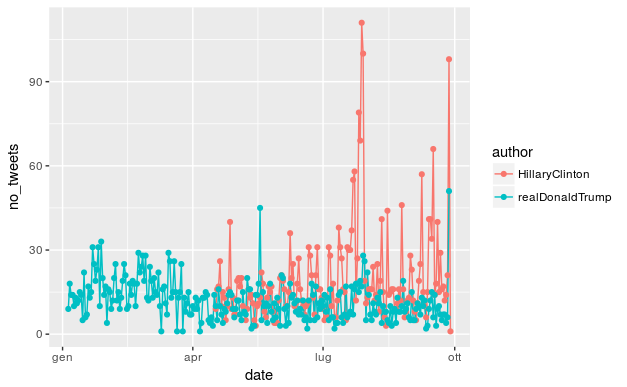

```r
tweet_summary_tbl %>%
  ggplot(aes(x = date, y = no_tweets, fill = author, colour = author)) +
  geom_line() +
  geom_point()
```

We can see that there’s a missing area in data that we should consider.

Hillary Clinton has very high picks.

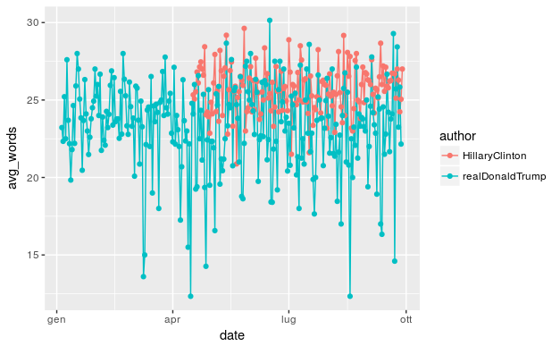

```r
tweet_summary_tbl %>%
  ggplot(aes(x = date, y = avg_words, fill = author, colour = author)) +
  geom_line() +
  geom_point()
```

Trump has very short tweets, sometimes.

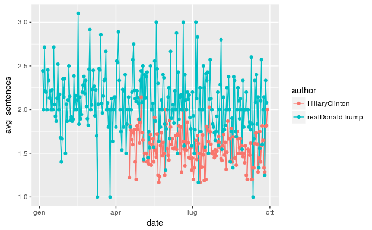

```r
tweet_summary_tbl %>%
  ggplot(aes(x = date, y = avg_sentences, fill = author, colour = author)) +
  geom_line() +
  geom_point()
```

Even if Hillary Clinton uses more words, she has an average number of sentences lower of Trump: Trump uses many short sentences

### Hour and author

```r
tweet_summary_tbl2 <- tweet_summary %>%
  group_by(author, hour) %>%
  summarize(no_tweets = n_distinct(Text),
            avg_words = mean(Tokens),
            avg_sentences = mean(Sentences))
```

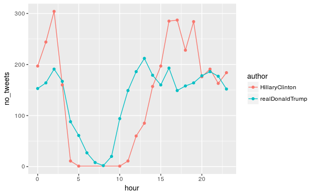

```r
tweet_summary_tbl2 %>%
  ggplot(aes(x = hour, y = no_tweets, fill = author, colour = author)) +
  geom_line() +
  geom_point()
```

Similar patterns, but Hillary Clinton has a longer drop off during night.

## dfm

Document Feature Matrix: a frequency table for each token per document.

From dfm starts the analysis.

Usually is sparse, with lots of zero. Sparse matrix can be trated as normal matrix but are stored in a more efficient way. dfm are sparse to optimize the code efficiency

```r
my_dfm
```

```
Document-feature matrix of: 6,444 documents, 14,121 features (99.9% sparse).
```

99.9% sparse

```r
my_dfm[1:10, 1:10]
```

### ngrams

```r
my_dfm2 <- dfm(tweet_corpus, ngrams = 2)
my_dfm2[1:10, 1:20]
```

```
Document-feature matrix of: 10 documents, 20 features (89.5% sparse).
10 x 20 sparse Matrix of class "dfm"
        features
docs     the_question question_in in_this this_election election_: :_who
  text1             1           1       1             1          1     1
  text2             0           0       0             0          0     0
  text3             0           0       0             0          0     0
  text4             0           0       0             0          0     0
  text5             0           0       0             0          0     0
  text6             0           0       0             0          0     0
  text7             0           0       0             1          0     0
  text8             0           0       0             0          0     0
  text9             0           0       0             0          0     0
  text10            0           0       0             0          0     0
        features
docs     who_can can_put put_the the_plans plans_into into_action action_that
  text1        1       1       1         1          1           1           1
  text2        0       0       0         0          0           0           0
  text3        0       0       0         0          0           0           0
  text4        0       0       0         0          0           0           0
  text5        0       0       0         0          0           0           0
  text6        0       0       0         0          0           0           0
  text7        0       0       0         0          0           0           0
  text8        0       0       0         0          0           0           0
  text9        0       0       0         0          0           0           0
  text10       0       0       0         0          0           0           0
        features
docs     that_will will_make make_your your_life life_better better_? ?_https
  text1          1         1         1         1           1        1       1
  text2          0         0         0         0           0        0       0
  text3          0         0         0         0           0        0       0
  text4          0         0         0         0           0        0       0
  text5          0         0         0         0           0        0       0
  text6          0         0         0         0           0        0       0
  text7          0         0         0         0           0        0       0
  text8          0         0         0         0           0        0       0
  text9          0         0         0         0           0        0       0
  text10         0         0         0         0           0        0       0
```

```r
my_dfm2
```

```
Document-feature matrix of: 6,444 documents, 61,132 features (100% sparse).
```

```r
my_dfm2
```

```
Document-feature matrix of: 6,444 documents, 61,132 features (100% sparse).
```

Number of features is grown, almost all zero.

### Top features

```r
topfeatures(my_dfm, 50)
```

```
               /                .                :             t.co
           12212             7441             5634             4021
           https                ,              the                "
            4019             3641             3591             3457
              to                !                a              and
            2828             2587             1994             1884
              in               of                -               is
            1688             1610             1567             1430
             for              you                i               on
            1304             1296             1168             1144
           trump          hillary               we             will
            1083             1030              967              807
              be             that               it              our
             800              768              628              613
            with            thank             this              are
             606              566              563              544
           great              not             have           donald
             532              528              511              489
              he               at @realdonaldtrump              all
             483              433              421              417
             who           people              has          america
             414              414              402              398
            just        president                ;              his
             394              385              384              380
               &                ?
             368              366
```

It’s not very clean: we have stop words, punctuation..

## Data cleaning

- Make all letters lower case
- Truncate words to the roots (ex: family and families)
- Remove repetitive words, stop words. There are dictionaries of stop words.
- Remove punctuation, urls, repetitive words

How to clean data is up to the analyst: sometimes punctuation or upper case are informative. On the other side sometimes some words are not informative (etc for an insurance company, the word “policy” is very frequent and not informative)

```r
edited_dfm <- dfm(tweet_corpus, remove_url = TRUE, remove_punct = TRUE, remove = stopwords("english"))
topfeatures(edited_dfm, 20)
```

```
                 trump                hillary                  thank
                  1083                   1030                    566
                 great                 donald       @realdonaldtrump
                   532                    489                    421
                people                america                   just
                   414                    398                    394
             president                    amp                   make
                   385                    360                    358
            #trump2016                    can                clinton
                   348                    318                    305
                   new                    one #makeamericagreatagain
                   281                    280                    254
                   get                    now
                   244                    241
```

#### Stopwords

There is the stopwords package that contains stopwords for many languages.

### Wordclouds

We can visualize the top features throug a wordcloud. If the wordcloud looks ugly, change the seed :D

```
min.freqcolorsrandom.orderrot.per is deprecated; use min_countcolorrandom_orderrotation instead
```

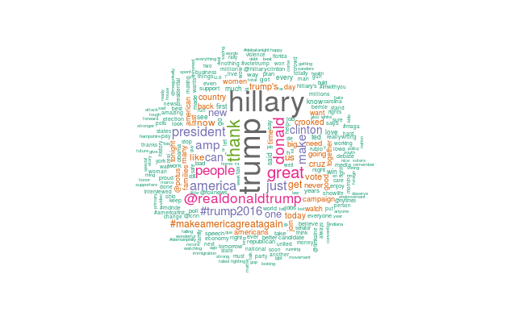

```r
set.seed(100)
textplot_wordcloud(edited_dfm,
                   min.freq = 40,
                   random.order = FALSE,
                   rot.per = .25,
                   colors = RColorBrewer::brewer.pal(8,"Dark2"))
```

They use their names a lot!

Wordclouds give a first impact of the text

### Comparison - Wordclouds by author

```r
by_author_dfm <- dfm(tweet_corpus,
                     groups = "author",
                     remove = stopwords("english"), remove_punct = TRUE, remove_url = TRUE)
by_author_dfm[1:2,1:10]
```

```
Document-feature matrix of: 2 documents, 10 features (0% sparse).
2 x 10 sparse Matrix of class "dfm"
                 features
docs              question election can put plans action make life better last
  HillaryClinton         5       60 223  34    20     13  189   50     60   57
  realDonaldTrump        5       22  95  29     8     12  169   11     36   89
```

```
min.freqcolorsrandom.orderrot.per is deprecated; use min_countcolorrandom_orderrotation instead
```

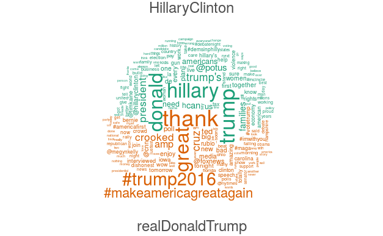

```r
set.seed(200)
textplot_wordcloud(by_author_dfm,
                   comparison = TRUE,
                   min.freq = 50,
                   random.order = FALSE,
                   rot.per = .25,
                   colors = RColorBrewer::brewer.pal(8,"Dark2"))
```

Now it’s a comparison. Trump says a lot of thank, while Hillary says a lot the names.

## tidy text

```r
library(tidytext)
tidy(dfm())
```

Good way to qickly explore data.

# Text modeling

We create a function that create the dfm matrix.

```r
get_matrix <- function(df){
  corpus <- quanteda::corpus(df)
  #dfm <- quanteda::dfm(corpus, tolower = TRUE, stem = TRUE, remove = c(stopwords("english"), "will"), ngrams = 1:2)
  dfm <- quanteda::dfm(corpus, remove_url = TRUE, remove_punct = TRUE,
                       remove = stopwords("english"))
}
```

We want to standardize training set and test set, so that they have the same features.

```r
set.seed(32984)
trainIndex <- sample.int(n = nrow(tweet_data),
                         size = floor(.8*nrow(tweet_data)), replace = F)
train_dfm <- get_matrix(tweet_data$text[trainIndex])
train_raw <- tweet_data[, c("text", "tweet_num")][as.vector(trainIndex), ]
train_labels <- tweet_data$author[as.vector(trainIndex)] == "realDonaldTrump"
test_dfm <- get_matrix(tweet_data$text[-trainIndex])
test_raw <- tweet_data[, c("text", "tweet_num")][-as.vector(trainIndex), ]
test_labels <- tweet_data$author[-as.vector(trainIndex)] == "realDonaldTrump"
```

```r
### make sure that train & test sets have exactly same features
test_dfm <- dfm_select(test_dfm, train_dfm)
# check that the train and test set have the same
all(train_dfm@Dimnames$features == test_dfm@Dimnames$features)
```

```
[1] TRUE
```

## Naive Bayes

```r
nb_model <- quanteda::textmodel_nb(train_dfm, train_labels)
nb_preds <- predict(nb_model, test_dfm)
```

Accuracy:

```r
print(mean(nb_preds$nb.predicted == test_labels))
```

```
[1] 0.9185415
```

The accuracy is not everything

## Understanding a model

Understanding a model is about trust

Should I trust the results of my prediction and take action accordingly?

Will the results give me my desired effect?

Is the model setted to work well in real life (eg there are cases not considered by my model?)

## LIME

Local: drivers for local areas - observation level

Interpretable: results are understandable

Model-agnostic: works on all models

Explanations: show the drivers of the model prediction

Can be used on text, images and numerical data.

What was important for that particular observation?

Assumes that at a local level you can run a linear regression. Often the relation between classes is not linear, but LIME trys to zoom into the data at a very local level, and then trys to find the linear regression that distinguish between the two.

LIME helps communication, because helps model understanding.

#### Husky vs wolf

An image wrongly classified as wolf, while it is an husky: if we look at the explanation, the model classified it wrongly looking at the background (snow)

### Example

```r
predictions_tbl <- data.frame(predict_label = nb_preds$nb.predicted,
                              actual_label = test_labels,
                              tweet_name = rownames(nb_preds$posterior.prob)
) %>%
  mutate(tweet_num =
           as.integer(
             str_trim(
               str_replace_all(tweet_name, "text", ""))
           ))
```